# Assignment 4

Rahmat Ashari

Apr 12, 2020

# Question 1, MS 7.118

## a

```r
data1 = read.csv('NZBIRDS.csv')

random = sample(1:116, 35, replace=F)

data1Random = data1[random,]
```

## b

```r
massMean = mean(data1Random$Body.Mass)
massSd = sd(data1Random$Body.Mass)

massMean
```

```
## [1] 6132.114
```

```r
massSd
```

```
## [1] 22849.95
```

```r
# 95% CI for body mass mean
t.test(data1Random$Body.Mass)
```

```
##
##  One Sample t-test
##
## data:  data1Random$Body.Mass
## t = 1.5877, df = 34, p-value = 0.1216
## alternative hypothesis: true mean is not equal to 0
## 95 percent confidence interval:
##  -1717.119 13981.348
## sample estimates:
## mean of x
##  6132.114
```

## c

Practical interpretation of 95% CI performed in b translates to: we are 95% confident that the mean of the population lies between the interval stated above in **c**.

## d

```r
massMeanTrue = mean(data1$Body.Mass)
massMeanTrue
```

```
## [1] 9113.043
```

Yes, the true mean is within the 95% CI. The interval is very likely to include the true mean because the sampling number is considered large and confidence interval is also large. This sampling configuration is likely to represent the population quite well.

## e

```r
meanEggL = mean(data1Random$Egg.Length)
sdEggL = sd(data1Random$Egg.Length)

meanEggL
```

```
## [1] 49.82857
```

```r
sdEggL
```

```
## [1] 40.01488
```

```r
# 95% CI for body egg legth
t.test(data1Random$Egg.Length)
```

```
##
##  One Sample t-test
##
## data:  data1Random$Egg.Length
## t = 7.367, df = 34, p-value = 1.54e-08
## alternative hypothesis: true mean is not equal to 0
## 95 percent confidence interval:
##  36.08298 63.57416
## sample estimates:
## mean of x
##  49.82857
```

```r
mean(na.omit(data1$Egg.Length))
```

```
## [1] 61.05652
```

The practical interpretation is analogous to answer in c, but change the variable of interest from body mass to egg length.

Check confirms that true population mean is witin the 95% CI.

## f

```r
# Extinct
pe = 21/38
qe = 1-pe
ne = 38

# Not extinct
pn = 7/78
qn = 1 - pn
nn = 78

# mean prop
meandiff5 = pe - pn

# z stat
zstat5 = qnorm(1 - (0.05/2), 0, 1)

dis5 = zstat5*((pe*qe/ne)+(pn*qn/nn))^0.5

low5 = meandiff5 - dis5
up5 = meandiff5 + dis5

low5
```

```
## [1] 0.2925475
```

```r
up5
```

```
## [1] 0.6332285
```

## g

Yes, there is evidence based on positive CI in c.

# Question 2, MS 7.120

## a

```r
zstat2 = qnorm(1 - 0.1/2, 0, 1)
meandiff2 = 1312-1352
devi2 = zstat2*((422^2/100) + (271^2/47))^0.5
lower2 = meandiff2 - devi2
upper2 = meandiff2 + devi2

# lower 90% CI
lower2
```

```
## [1] -135.1092
```

```r
# upper 90% CI
upper2
```

```
## [1] 55.10916
```

## b

```r
fstat2l = qf(1 - 0.1/2, 100 -1, 47 -1)
fstat2u = qf(1 - 0.1/2, 47 -1, 100 -1)

lower2b = (422^2/271^2)*(1/fstat2l)
upper2b = (422^2/271^2)*fstat2u

lower2b
```

```
## [1] 1.566267
```

```r
upper2b
```

```
## [1] 3.61775
```

# Question 3, MS 7.128

## a

$$Z = \frac{y - \mu}{\sigma} = \frac{y - 0}{\sigma}$$
$$Z = \frac{y}{\sigma}$$

The equation above will have a normal distribution. However, if we square both side,

$$Z^2 = \frac{y^2}{\sigma^2}$$

This equation will follow $\chi^2$ distribution.

## b

$$P(\chi^2_{1-\alpha/2} \leq \frac{y^2}{\sigma^2} \leq \chi^2_{\alpha/2}) = 1 - \alpha$$
$$P(\frac{1}{\chi^2_{1-\alpha/2}} \geq \frac{\sigma^2}{y^2} \geq \frac{1}{\chi^2_{\alpha/2}}) = 1 - \alpha$$
$$P(\frac{y^2}{\chi^2_{\alpha/2}} \leq \sigma^2 \leq \frac{y^2}{\chi^2_{1-\alpha/2}}) = 1 - \alpha$$

for 95% CI, $\alpha$ = 0.05

```r
lowchi = qchisq(1 - 0.05/2, 1)
upchi = qchisq(0.05/2, 1)

round(lowchi,4)
```

```
## [1] 5.0239
```

```r
round(upchi, 4)
```

```
## [1] 0.001
```

Lower interval:
$$\frac{y^2}{5.0239}$$

Upper interval:
$$\frac{y^2}{0.001}$$

# Question 4, MS 8.24

```r
data8 = read.csv("ROUGHPIPE.csv")
```

## a

$$H_0 : \mu = 2$$
$$H_1 : \mu \neq 2$$

## b

From the MINITAB, t-stat is -1.02 and p-value is 0.322

## c

Reject when y < 1.63580 and y > 2.12620

## d

Because p>$\alpha$ and the value of 2 is within the acceptance region (= 0.05), it is plausible that $\mu$ is 2.

## e

The confidence interval is built with test statistics.

# Question 5, MS 8.28

```r
DOC = c(9.6,4.5,13.2,4.1,22.6,2.7,14.7,3.5,13.6,19.8,14.3,56.9,25.1,18.4,2.7,4.2,30.2,10.3,17.6,2.4,17.3,38.8,3.0,5.8,7.6)
```

## a

```r
t.test(DOC, mu=15, conf.level = 0.9)
```

```
##
##  One Sample t-test
##
## data:  DOC
## t = -0.18668, df = 24, p-value = 0.8535
## alternative hypothesis: true mean is not equal to 15
## 90 percent confidence interval:
##  10.08013 18.95187
## sample estimates:
## mean of x
##    14.516
```

The one sample t test shows p>$\alpha$ and the null value within 90% CI. Hence, it is plausible that the sample is representative of the population.

## b

```r
tstat5 = qt(1-0.1/2, 25-1)
low5 = 15 - tstat5*(sd(DOC)/25^0.5)
up5 = 15 + tstat5*(sd(DOC)/25^0.5)

tLess14 = (low5 - 14)/(sd(DOC)/25^0.5)
tMore14 = (up5 - 14)/(sd(DOC)/25^0.5)

pt(tLess14, df = 25-1) + (1-pt(tMore14, df = 25-1))
```

```
## [1] 0.1221688
```

# Question 6, MS 8.44

```r
data6 = read.csv('ORCHARD.csv')
data6g = na.omit(data6)

fog = data6g[data6g$CONDITION =='FOG', 'RATIO']

cleClou = data6g[data6g$CONDITION =='CLEAR' | data6g$CONDITION =='CLOUD', 'RATIO']

t.test(fog, cleClou, mu = 0, var.equal = T)
```

```
##
##  Two Sample t-test
##
## data:  fog and cleClou
## t = -2.0467, df = 10, p-value = 0.06788
## alternative hypothesis: true difference in means is not equal to 0
## 95 percent confidence interval:
##  -0.37281919  0.01581919
## sample estimates:
## mean of x mean of y
##   0.27375   0.45225
```

The problem above was configured such that $H_0: \mu_1 - \mu_2 = 0$. With p slightly greater than $\alpha$ and the null value is within the 95% CI, it is plausible that the population means to be similar.

# Question 7, MS 8.84

```r
data7 = read.csv('GASTURBINE.csv')
```

## a

```r
traditional = data7[data7$ENGINE =='Traditional', 'HEATRATE']
aeroder = data7[data7$ENGINE == 'Aeroderiv', 'HEATRATE']

var.test(aeroder, traditional)
```

```
##
##  F test to compare two variances
##
## data:  aeroder and traditional
## F = 4.297, num df = 6, denom df = 38, p-value = 0.004234
## alternative hypothesis: true ratio of variances is not equal to 1
## 95 percent confidence interval:
##   1.555004 21.574593
## sample estimates:
## ratio of variances
##           4.296996
```

The p value is smaller than $\alpha$ = 0.05 and the null value is not within the CI. Hence, it is not plausible that the ratio to be 1, which translates to the variances of the two vectors to be different.

Here, we compare the variance of traditional engine to aeroderivative engine. Ratio of variance is far from one. Inference of population means must be performed with Welch test.

## b

```r
advanced = data7[data7$ENGINE == 'Advanced', 'HEATRATE']

var.test(aeroder, advanced)
```

```
##
##  F test to compare two variances
##
## data:  aeroder and advanced
## F = 17.249, num df = 6, denom df = 20, p-value = 1.192e-06
## alternative hypothesis: true ratio of variances is not equal to 1
## 95 percent confidence interval:
##   5.513829 89.150428
## sample estimates:
## ratio of variances
##           17.24913
```

Same conclusion as in **a**

# Question 8, MS 8.99

```r
ant = read.csv('GOBIANTS.csv')
```

## a

$$H_0: \frac{\sigma^2_{1}}{\sigma^2_{2}} = 1$$
$$H_0: \frac{\sigma^2_{1}}{\sigma^2_{2}} \neq 1$$

## b

```r
dry = ant[ant$Region == 'Dry Steppe ', 'AntSpecies']
gobi = ant[ant$Region == 'Gobi Desert', 'AntSpecies']

t.test(dry, gobi, var.equal = T)
```

```
##
##  Two Sample t-test
##
## data:  dry and gobi
## t = 0.1821, df = 9, p-value = 0.8595
## alternative hypothesis: true difference in means is not equal to 0
## 95 percent confidence interval:
##  -24.74894  29.08228
## sample estimates:
## mean of x mean of y
##  14.00000  11.83333
```

```r
var.test(dry, gobi)
```

```
##
##  F test to compare two variances
##
## data:  dry and gobi
## F = 1.3684, num df = 4, denom df = 5, p-value = 0.7264
## alternative hypothesis: true ratio of variances is not equal to 1
## 95 percent confidence interval:
##   0.1852264 12.8146380
## sample estimates:
## ratio of variances
##           1.368432
```

t is 0.1821

## c

```r
round(qf(c(0.05,1 - 0.05/2), length(dry) - 1, length(gobi) -1), 4)
```

```
## [1] 0.1598 7.3879
```

rejection region is when F<0.1598 and F>7.3879

## d

From t.test in **b**, p-value = 0.8595

## e

From `var.test()` in **b**, because p-value > $\alpha$ and the null value of 1 is within the 95% CI, we conclude that it is plausible for the population variance to be similar.

## d

This holds truth for independent samples.

# Question 9, MS 8.104

```r
data9 = read.csv('THRUPUT.csv')

var.test(data9$HUMAN, data9$AUTO)
```

```
##
##  F test to compare two variances
##
## data:  data9$HUMAN and data9$AUTO
## F = 0.84111, num df = 7, denom df = 7, p-value = 0.8253
## alternative hypothesis: true ratio of variances is not equal to 1
## 95 percent confidence interval:
##  0.168394 4.201283
## sample estimates:
## ratio of variances
##           0.841113
```

From the `var.test()`, we can conclude that it is plausible for the variances to be the same for this paired samples. We can set the hypothesis:

$$H_0: \mu_{human} - \mu_{auto} = 0$$

$$H_0: \mu_{human} - \mu_{auto} \neq 0$$

```r
t.test(data9$HUMAN, data9$AUTO, paired = T, var.equal = T, mu = 0)
```

```
##
##  Paired t-test
##
## data:  data9$HUMAN and data9$AUTO
## t = -2.629, df = 7, p-value = 0.03396
## alternative hypothesis: true difference in means is not equal to 0
## 95 percent confidence interval:
##  -61.850346  -3.274654
## sample estimates:
## mean of the differences
##                -32.5625
```

From `t.test()`, we observe p-value < $\alpha$, which is 0.05 in this case. We further notice the fact that the null value is not within the 95% CI. Therefore, we conclude that the NULL hypothesis is not plausible, that is the population means for each scheduling method are different.

# Question 10

```r
myboot<-function(iter=10000,x,fun="mean",alpha=0.05, D0 = 0,...){
n=length(x)

y=sample(x,n*iter,replace=TRUE)
rs.mat=matrix(y,nr=n,nc=iter,byrow=TRUE)
xstat=apply(rs.mat,2,fun)
ci=quantile(xstat,c(alpha/2,1-alpha/2))
# A histogram follows
# The object para will contain the parameters used to make the histogram
para=hist(xstat,freq=FALSE,las=1,
main=paste("Histogram of Bootstrap sample statistics","\n","alpha=",alpha," iter=",iter,sep=""),
...)

#mat will be a matrix that contains the data, this is done so that I can use apply()
mat=matrix(x,nr=length(x),nc=1,byrow=TRUE)

#pte is the point estimate
#This uses whatever fun is
pte=apply(mat,2,fun)
abline(v=pte,lwd=3,col="Black")# Vertical line
segments(ci[1],0,ci[2],0,lwd=4)      #Make the segment for the ci
text(ci[1],0,paste("(",round(ci[1],2),sep=""),col="Red",cex=3)
text(ci[2],0,paste(round(ci[2],2),")",sep=""),col="Red",cex=3)

obj = t.test(sam, mu = D0)
lower = round(obj$conf.int[1],2)
upper = round(obj$conf.int[2],2)
text(lower,0.2,paste("(",lower,sep=""),col="Blue",cex=3)
text(upper,0.2,paste(upper,")",sep=""),col="Blue",cex=3)

# plot the point estimate 1/2 way up the density
text(pte,max(para$density)/2,round(pte,2),cex=3)

return(list(ci=ci,fun=fun,x=x, t=obj$statistic, cit=obj$conf.int))# Some output to use if necessary
}
```

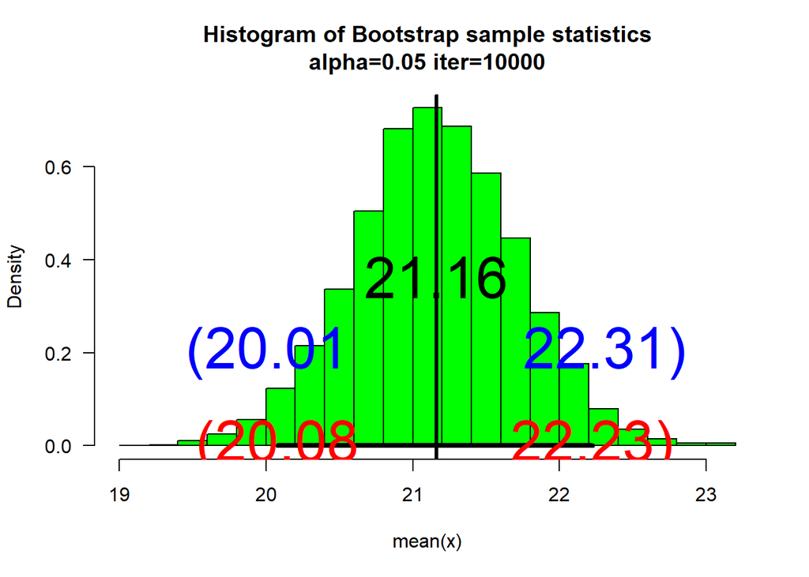

```
## $ci
##     2.5%    97.5%
## 20.07910 22.22545
##
## $fun
## [1] "mean"
##
## $x
##  [1] 23.195 20.399 19.898 19.865 30.014 18.821 21.232 18.313 23.574 21.047
## [11] 21.535 21.336 17.695 18.497 14.274 14.664 22.593 18.963 25.515 25.019
## [21] 22.053 22.871 23.006 23.829 19.038 21.735 21.461 21.659 21.703 21.049
##
## $t
##        t
## 2.065773
##
## $cit
## [1] 20.01155 22.31198
## attr(,"conf.level")
## [1] 0.95
```

```r
set.seed(35)
sam<-round(rnorm(30,mean=20,sd=3),3)
myboot(10000,x=sam,alpha=0.05,xlab="mean(x)",col="green", D0 = 20)
```